# 1_data_review

## Homework #4. Exploratory Data Analysis

#### Author: `Roman Malynovskyi`

#### Total time spent on h/w (in minutes): `1200`

```python
import pandas as pd
```

```python
DIALOGS_MERGED_DATA_PATH = "../data/merged_data/dialogs_data_all.csv"
DIALOGS_META_MERGED_DATA_PATH = "../data/merged_data/dialogs_users_all.csv"
```

```python
df = pd.read_csv(DIALOGS_MERGED_DATA_PATH)
df_meta = pd.read_csv(DIALOGS_META_MERGED_DATA_PATH)
```

## Task 2.1

## Messages data analysis

```python
df.head(10)
```

|  | id | date | from_id | to_id | fwd_from | message | type | duration | reactions | dialog_id |
| --- | --- | --- | --- | --- | --- | --- | --- | --- | --- | --- |
| 0 | 170803 | 2023-06-16 08:39:46+00:00 | NaN | 749006059 | NaN | думаешь у меня есть желание с тобой говорить? ... | text | NaN | {} | 611662350 |
| 1 | 170802 | 2023-06-16 08:06:56+00:00 | PeerUser(user_id=749006059) | 611662350 | NaN | хулі ігнориш | text | NaN | {} | 611662350 |
| 2 | 170786 | 2023-06-15 18:45:18+00:00 | PeerUser(user_id=749006059) | 611662350 | NaN | Ти вже писав нмт? | text | NaN | {} | 611662350 |
| 3 | 170785 | 2023-06-15 18:45:13+00:00 | PeerUser(user_id=749006059) | 611662350 | NaN | Доров | text | NaN | {} | 611662350 |
| 4 | 114007 | 2022-11-19 10:26:19+00:00 | PeerUser(user_id=749006059) | 611662350 | NaN | Ясно | text | NaN | {} | 611662350 |
| 5 | 114004 | 2022-11-19 10:02:06+00:00 | NaN | 749006059 | NaN | а "Іванов" це одне з найчастіших імен | text | NaN | {} | 611662350 |
| 6 | 114003 | 2022-11-19 10:01:48+00:00 | NaN | 749006059 | NaN | ти сам здається підписався просто як roman, ні? | text | NaN | {} | 611662350 |
| 7 | 114002 | 2022-11-19 10:01:33+00:00 | NaN | 749006059 | NaN | NaN | text | NaN | {} | 611662350 |
| 8 | 114001 | 2022-11-19 10:01:26+00:00 | NaN | 749006059 | NaN | бо трохи не полюбляю виставляти ім'я в інтернеті | text | NaN | {} | 611662350 |
| 9 | 114000 | 2022-11-19 09:57:34+00:00 | PeerUser(user_id=749006059) | 611662350 | NaN | Чому ти підписаний "Іванов"? Якщо не секрет | text | NaN | {} | 611662350 |

```python
df.shape
```

```
(3319910, 10)
```

```python
min(df["date"]),max(df["date"])
```

```
('2017-05-29 04:52:49+00:00', '2024-10-26 15:44:01+00:00')
```

```python
df.groupby(["type"])["type"].count()
```

```
type
photo       448975
sticker      53407
text       2666241
video       144959
voice         6328
Name: type, dtype: int64
```

```python
df.groupby(["type"])["duration"].sum()
```

```
type
photo      0.000000e+00
sticker    0.000000e+00
text       0.000000e+00
video      7.120848e+06
voice      1.387230e+05
Name: duration, dtype: float64
```

## Tasks to do:

1. Define your telegram ID (https://www.alphr.com/telegram-find-user-id/).

```python
id=749006059
```

2. Check on examples that the data you downloaded reflects your telegram messages. Make screenshots (insert your screenshots in this notebook) of 3 different messages in TG and related rows in your dataset here.

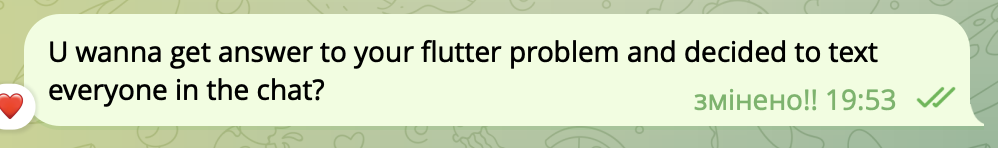

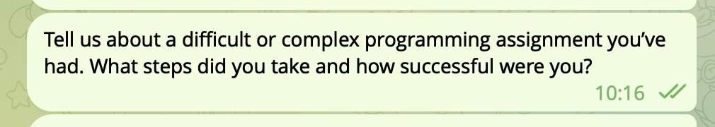

[figure not shown]

```python
message_text = "U wanna get answer to your flutter problem and decided to text everyone in the chat?"
df[df['message'].str.contains(message_text, na=False)]
```

|  | id | date | from_id | to_id | fwd_from | message | type | duration | reactions | dialog_id |
| --- | --- | --- | --- | --- | --- | --- | --- | --- | --- | --- |
| 1692737 | 182494 | 2023-08-04 16:53:54+00:00 | PeerUser(user_id=749006059) | 5853701578 | NaN | U wanna get answer to your flutter problem and... | text | NaN | {} | 5853701578 |

```python
message_text = "Tell us about a difficult or complex programming assignment you’ve had. What steps did you take and how successful were you?"
df[df['message'].str.contains(message_text, na=False)]
```

|  | id | date | from_id | to_id | fwd_from | message | type | duration | reactions | dialog_id |
| --- | --- | --- | --- | --- | --- | --- | --- | --- | --- | --- |
| 1237953 | 275482 | 2024-10-11 07:16:25+00:00 | PeerUser(user_id=749006059) | 879649020 | NaN | Tell us about a difficult or complex programmi... | text | NaN | {} | 879649020 |
| 1237954 | 275481 | 2024-10-11 07:15:52+00:00 | PeerUser(user_id=749006059) | 879649020 | NaN | Software engineers, programmers, and other IT ... | text | NaN | {} | 879649020 |
| 1237958 | 275477 | 2024-10-11 07:14:07+00:00 | PeerUser(user_id=749006059) | 879649020 | NaN | Cooks and food prep workers\nHow would you des... | text | NaN | {} | 879649020 |

```python
message_text = "Minecraft movie"
df[df['message'].str.contains(message_text, na=False)]
```

|  | id | date | from_id | to_id | fwd_from | message | type | duration | reactions | dialog_id |
| --- | --- | --- | --- | --- | --- | --- | --- | --- | --- | --- |
| 2777140 | 273515 | 2024-10-02 19:25:06+00:00 | PeerUser(user_id=749006059) | 1072036174 | NaN | Minecraft movie | video | 9.0 | {} | 1072036174 |

3. Find the longest audio message you've ever sent; what's its duration? Make its screenshot (insert your screenshots in this notebook).

[figure not shown]

```python
voice_messages = df[df['from_id'].astype(str).str.contains(str(id), na=False)][df['type'] == 'voice']

longest_voice_message = voice_messages.loc[voice_messages['duration'].idxmax()]
longest_voice_message
```

```
id                                                      195464
date                                 2023-09-28 05:06:47+00:00
from_id                            PeerUser(user_id=749006059)
to_id                                                662375298
fwd_from     MessageFwdHeader(date=datetime.datetime(2020, ...
message                                                    NaN
type                                                     voice
duration                                                 489.0
reactions                                                   {}
dialog_id                                            662375298
Name: 916546, dtype: object
```

4. Calculate numbers of send and received(s&r) messages.

```python
sent_messages_count = df[df['from_id'].astype(str).str.contains(str(id))].shape[0]
received_messages_count = df[df['to_id'].astype(str).str.contains(str(id))].shape[0]
sent_messages_count, received_messages_count
```

```
(221653, 87291)
```

5. Draw number of send and received(s&r) messages per day (x-axis - is date(from min(date) till max(date)), y-axis number of messages). There should be two lines: blue for received red for send.

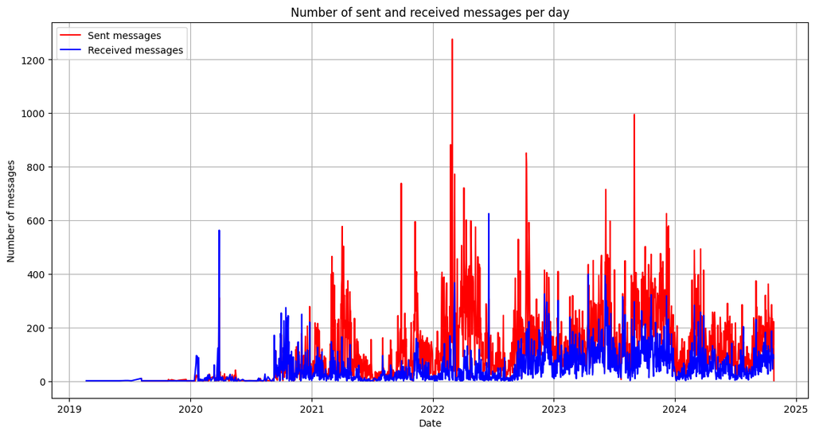

```python
import matplotlib.pyplot as plt

df['date'] = pd.to_datetime(df['date'])

sent_messages = df[df['from_id'].astype(str).str.contains(str(id))]
received_messages = df[df['to_id'].astype(str).str.contains(str(id))]

sent_messages_per_day = sent_messages.groupby(sent_messages['date'].dt.date).size()
received_messages_per_day = received_messages.groupby(received_messages['date'].dt.date).size()

min_date = min(sent_messages['date'].min(), received_messages['date'].min()).date()
max_date = max(sent_messages['date'].max(), received_messages['date'].max()).date()
date_range = pd.date_range(start=min_date, end=max_date)

plt.figure(figsize=(14, 7))
plt.plot(sent_messages_per_day.index, sent_messages_per_day.values, label='Sent messages', color='red')
plt.plot(received_messages_per_day.index, received_messages_per_day.values, label='Received messages', color='blue')
plt.xlabel('Date')
plt.ylabel('Number of messages')
plt.title('Number of sent and received messages per day')
plt.legend(loc='upper left')
plt.grid(True)

plt.show()
```

```python
df['date'] = pd.to_datetime(df['date'])

sent_messages = df[df['from_id'].astype(str).str.contains(str(id))]
received_messages = df[df['to_id'].astype(str).str.contains(str(id))]

sent_messages_per_day = sent_messages.groupby(sent_messages['date'].dt.date).size()
received_messages_per_day = received_messages.groupby(received_messages['date'].dt.date).size()

top_10_sent_peaks = sent_messages_per_day.nlargest(10)
top_10_received_peaks = received_messages_per_day.nlargest(10)

(top_10_sent_peaks, top_10_received_peaks)
```

```
(date
 2022-03-01    1276
 2023-09-01     995
 2022-02-24     882
 2022-10-10     851
 2022-10-11     812
 2022-03-08     772
 2021-09-28     738
 2022-04-05     721
 2023-06-07     715
 2023-12-07     625
 dtype: int64,
 date
 2022-06-19    625
 2020-03-28    563
 2023-04-15    399
 2023-06-05    394
 2022-03-08    367
 2023-06-07    361
 2022-12-04    325
 2023-10-22    322
 2023-12-07    318
 2023-07-28    315
 dtype: int64)
```

```python
messages_on_date = df[(df['date'].dt.date == pd.to_datetime('2020-03-28').date()) & (df['to_id'].astype(str).str.contains(str(id)))]
messages_on_date['message_length'] = messages_on_date['message'].astype(str).apply(len)
longest_messages = messages_on_date.sort_values(by='message_length', ascending=False).head(10)
longest_messages[['date', 'message', 'message_length']]
```

|  | date | message | message_length |
| --- | --- | --- | --- |
| 3084206 | 2020-03-28 14:35:59+00:00 | ---------- 12.02.2020 ----------\n1. Вставні т... | 756 |
| 3084125 | 2020-03-28 14:36:23+00:00 | ---------- 12.02.2020 ----------\n1. Вставні т... | 756 |
| 3084247 | 2020-03-28 14:35:52+00:00 | ---------- 12.02.2020 ----------\n1. Вставні т... | 756 |
| 3084417 | 2020-03-28 14:35:32+00:00 | ---------- 12.02.2020 ----------\n1. Вставні т... | 756 |
| 3084521 | 2020-03-28 14:35:25+00:00 | ---------- 12.02.2020 ----------\n1. Вставні т... | 756 |
| 3084431 | 2020-03-28 14:35:32+00:00 | ---------- 12.02.2020 ----------\n1. Вставні т... | 756 |
| 3084271 | 2020-03-28 14:35:48+00:00 | ---------- 12.02.2020 ----------\n1. Вставні т... | 756 |
| 3084284 | 2020-03-28 14:35:46+00:00 | ---------- 12.02.2020 ----------\n1. Вставні т... | 756 |
| 3084210 | 2020-03-28 14:35:58+00:00 | ---------- 12.02.2020 ----------\n1. Вставні т... | 756 |
| 3084258 | 2020-03-28 14:35:50+00:00 | ---------- 12.02.2020 ----------\n1. Вставні т... | 756 |

6. Draw a few diagrams to show distributions between post types in the time, a diagram showing the total amount of messages of each type.

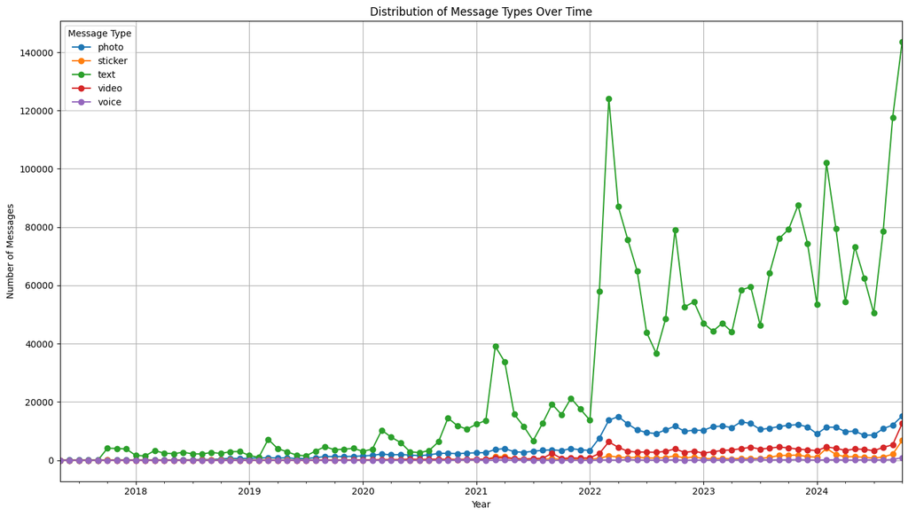

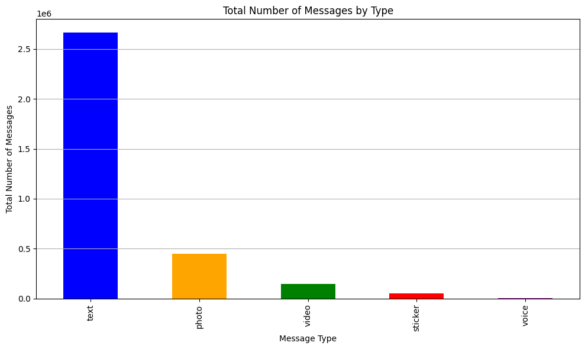

```python
df['date'] = pd.to_datetime(df['date'], errors='coerce')

df['year_month'] = df['date'].dt.to_period('M')

message_types_over_time = df.groupby(['year_month', 'type']).size().unstack(fill_value=0)

message_types_total = df['type'].value_counts()

plt.figure(figsize=(14, 8))
message_types_over_time.plot(ax=plt.gca(), kind='line', marker='o')
plt.xlabel('Year')
plt.ylabel('Number of Messages')
plt.title('Distribution of Message Types Over Time')
plt.legend(title='Message Type')
plt.grid(True)
plt.tight_layout()
plt.show()

plt.figure(figsize=(10, 6))
message_types_total.plot(kind='bar', color=['blue', 'orange', 'green', 'red', 'purple'])
plt.xlabel('Message Type')
plt.ylabel('Total Number of Messages')
plt.title('Total Number of Messages by Type')
plt.grid(axis='y')
plt.tight_layout()
plt.show()
```

7. Calculate top-10 people to whom you wrote the biggest amount of messages (name, amount of messages).

```python
import re

def process_id(to_id):
    try:
        return int(to_id)
    except ValueError:
        return None

top = df[df['from_id'].astype(str).str.contains(str(id), na=False)] \
                    .groupby('to_id') \
                    .size() \
                    .reset_index(name='message_count') \
                    .sort_values(by='message_count', ascending=False)

top['to_id'] = top['to_id'].apply(process_id)
top = top.dropna(subset=['to_id'])

valid = []

for _, row in top.iterrows():
    user_id = row['to_id']
    matching_record = df_meta[df_meta['dialog_id'] == user_id]

    valid.append({
        'name': matching_record.iloc[0]['name'],
        'message_count': row['message_count']
    })

    if len(valid) == 10:
        break

for item in valid:
    print(f"Name: {item['name']}, Message Count: {item['message_count']}")
```

```
Name: Діма Авдєєнко, Message Count: 16313.0
Name: Яроslave, Message Count: 10119.0
Name: Андрійко Гаспид, Message Count: 6856.0
Name: Рома Козлов, Message Count: 6377.0
Name: Мама, Message Count: 5839.0
Name: Сіль, Message Count: 4947.0
Name: PyPcDeV, Message Count: 4414.0
Name: Артур УФМЛ, Message Count: 3827.0
Name: Ярина Савчук, Message Count: 3632.0
Name: Alex, Message Count: 3556.0
```

8. Calculate top-10 people who wrote the biggest amount of messages to you (name, amount of messages).

```python
top = df[df['to_id'].astype(str).str.contains(str(id), na=False)] \
                    .groupby('dialog_id') \
                    .size() \
                    .reset_index(name='message_count') \
                    .sort_values(by='message_count', ascending=False)

top = top.dropna(subset=['dialog_id'])

valid = []

for _, row in top.iterrows():
    dialog_id = row['dialog_id']
    matching_record = df_meta[df_meta['dialog_id'] == dialog_id]

    if not matching_record.empty:
        valid.append({
            'dialog_id': dialog_id,
            'name': matching_record.iloc[0]['name'],
            'message_count': row['message_count']
        })

    if len(valid) == 10:
        break

for item in valid:
    print(f"Name: {item['name']}, Message Count: {item['message_count']}")
```

```
Name: Діма Авдєєнко, Message Count: 11518
Name: Яроslave, Message Count: 6314
Name: Мама, Message Count: 5775
Name: True Mafia, Message Count: 5397
Name: Рома Козлов, Message Count: 5162
Name: Андрійко Гаспид, Message Count: 4654
Name: Сіль, Message Count: 4338
Name: Артур УФМЛ, Message Count: 3783
Name: PyPcDeV, Message Count: 3779
Name: Ярина Савчук, Message Count: 2940
```

## Task 2.2

## Dialogs data analysis

```python
df_meta.shape
```

```
(10941, 4)
```

```python
df_meta.head(10)
```

|  | dialog_id | name | type | users |
| --- | --- | --- | --- | --- |
| 0 | 1032732069 | StikStok Bot | Private dialog | {'user_id': 1032732069, 'first_name': 'StikSto... |
| 1 | 810142558 | Masha | Private dialog | {'user_id': 810142558, 'first_name': 'Masha', ... |
| 2 | 942619663 | diana | Private dialog | {'user_id': 942619663, 'first_name': 'diana', ... |
| 3 | -1001695031361 | Могилянський Кібер-плац | Group | {'user_id': 749006059, 'first_name': 'Roman', ... |
| 4 | -1001695031361 | Могилянський Кібер-плац | Group | {'user_id': 772664687, 'first_name': 'Яроslave... |
| 5 | -1001695031361 | Могилянський Кібер-плац | Group | {'user_id': 625985176, 'first_name': 'Myroslav... |
| 6 | -1001695031361 | Могилянський Кібер-плац | Group | {'user_id': 519270613, 'first_name': 'Діма', '... |
| 7 | -1001695031361 | Могилянський Кібер-плац | Group | {'user_id': 938254248, 'first_name': 'Влад', '... |
| 8 | -1001695031361 | Могилянський Кібер-плац | Group | {'user_id': 482979767, 'first_name': 'Лізочка ... |
| 9 | -1001695031361 | Могилянський Кібер-плац | Group | {'user_id': 398760267, 'first_name': 'Андрій',... |

```python
df_meta.groupby(["type"])["type"].count()
```

```
type
Channel             127
Group             10528
Private dialog      286
Name: type, dtype: int64
```

## Tasks to do:

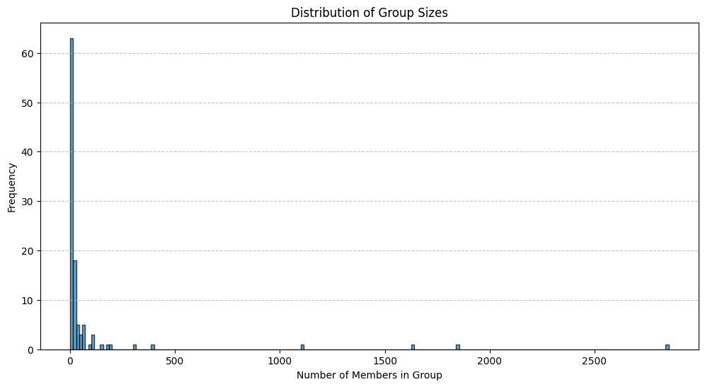

```python
group_sizes = df_meta[df_meta['type'] == 'Group'].groupby('dialog_id').size()

plt.figure(figsize=(12, 6))
plt.hist(group_sizes, bins=200, edgecolor='k', alpha=0.7)
plt.title('Distribution of Group Sizes')
plt.xlabel('Number of Members in Group')
plt.ylabel('Frequency')
plt.grid(axis='y', linestyle='--', alpha=0.7)
plt.show()
```

3. Calculate top-10 the biggest groups/channels.

```python
groups = df_meta.loc[df_meta['type'] == 'Group'].groupby(['dialog_id', 'name', 'type']).size().reset_index(name='user_count').sort_values(by='user_count', ascending=False)
groups.head(10)
```

|  | dialog_id | name | type | user_count |
| --- | --- | --- | --- | --- |
| 38 | -1001447409347 | Flutter App Development \| Community | Group | 2853 |
| 54 | -1001218251741 | Baraholka NaUKMA Chat | Group | 1852 |
| 24 | -1001695031361 | Могилянський Кібер-плац | Group | 1634 |
| 55 | -1001142723513 | ФІ | Group | 1109 |
| 11 | -1001980164786 | Другокурсник ФКНК | Group | 392 |
| 41 | -1001423156656 | Фреш-матгурток 🔱 | Group | 310 |
| 47 | -1001276915380 | буд майданчик | Group | 188 |
| 22 | -1001731108881 | Наше Світло Софія | Group | 185 |
| 17 | -1001906113211 | фі-2 | Group | 153 |
| 20 | -1001837879932 | Сусіди | Group | 115 |

```python
channels = df_meta.loc[df_meta['type'] == 'Channel'].groupby(['dialog_id', 'name', 'type']).size().reset_index(name='user_count').sort_values(by='user_count', ascending=False)
channels.head(10)
```

|  | dialog_id | name | type | user_count |
| --- | --- | --- | --- | --- |
| 16 | -1001879010850 | Важлива інфа | Channel | 58 |
| 51 | -1001591506891 | Фрази Лютого | Channel | 11 |
| 31 | -1001799663161 | прога | Channel | 2 |
| 32 | -1001789639449 | топові фільми | Channel | 1 |
| 33 | -1001783742463 | Ідеї | Channel | 1 |
| 34 | -1001780125933 | Дкри | Channel | 1 |
| 35 | -1001776367720 | НМТ | Channel | 1 |
| 36 | -1001771023437 | зно | Channel | 1 |
| 37 | -1001765021174 | Топові книги | Channel | 1 |
| 38 | -1001746168529 | ds | Channel | 1 |

4. Calculate the number of distinct user names you are connected to through any type of dialogue.

```python
users_models = df_meta['users']
users = set()
for user_list in users_models:
    users.add(user_list.split(',')[0].split(' ')[1])
len(users)
```

```
7713
```

Issues:

After some time original script was starting to send errors: Server sent a very old message with ID 7428741265596086273, ignoring Server sent a very old message with ID 7428741271254929409, ignoring Server sent a very old message with ID 7428741277087038465, ignoring Server sent a very old message with ID 7428741283355496449, ignoring Server sent a very old message with ID 7428741304305639425, ignoring Server sent a very old message with ID 7428741341416472577, ignoring

After which I had to restart script and all progress was lost.

So I upgraded script and make PR which you can see in this link: https://github.com/SanGreel/telegram-data-collection/pull/21 Here script looks for progress in output directory and continues from progress made there, so even if it fails, I don’t need to start from scratch.. Additionally, it downloads dialogs in batches of 10,000 messages and saves.